# Hierarchical Models · TuringGLM.jl

[Edit on GitHub](https://github.com/TuringLang/TuringGLM.jl/blob/master/docs/src/tutorials/hierarchical_models.md#)

Currently, TuringGLM only supports hierarchical models with a single random-intercept. This is done by using the `(1 | group)` inside the `@formula` macro.

For our **Hierarchical Model** example, let's use a famous dataset called `cheese` (Boatwright, McCulloch & Rossi, 1999), which is data from cheese ratings. A group of 10 rural and 10 urban raters rated 4 types of different cheeses (A, B, C and D) in two samples. So we have $4 \cdot 20 \cdot 2 = 160$ observations and 4 variables:

- `cheese`: type of cheese from `A` to `D`
- `rater`: id of the rater from `1` to `10`
- `background`: type of rater, either `rural` or `urban`
- `y`: rating of the cheese

```julia
using CSV
```

```julia
using DataFrames
```

```julia
url = "https://github.com/TuringLang/TuringGLM.jl/raw/main/data/cheese.csv";
```

```julia
cheese = CSV.read(download(url), DataFrame)
```

| cheese | rater | background | y |
| --- | --- | --- | --- |
| "A" | 1 | "rural" | 67 |
| "A" | 1 | "rural" | 66 |
| "B" | 1 | "rural" | 51 |
| "B" | 1 | "rural" | 53 |
| "C" | 1 | "rural" | 75 |
| "C" | 1 | "rural" | 70 |
| "D" | 1 | "rural" | 68 |
| "D" | 1 | "rural" | 66 |
| "A" | 2 | "rural" | 76 |
| "A" | 2 | "rural" | 76 |
| ... |  |  |  |
| "D" | 10 | "urban" | 83 |

```julia
using TuringGLM
```

Using `y` as dependent variable and `background` is independent variable with a varying-intercept per `cheese` type:

```julia
fm = @formula(y ~ (1 | cheese) + background)
```

```
FormulaTerm
Response:
  y(unknown)
Predictors:
  (cheese)->1 | cheese
  background(unknown)
```

We instantiate our model with `turing_model` without specifying any model, thus the default model will be used (`model=Normal`):

```julia
model = turing_model(fm, cheese);
```

```julia
chn = sample(model, NUTS(), 2_000);
```

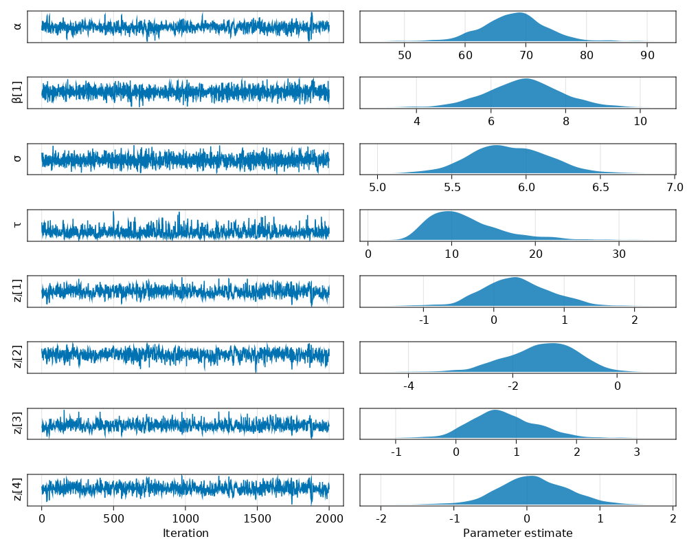

```julia
plot_chains(chn)
```

## References

Boatwright, P., McCulloch, R., & Rossi, P. (1999). Account-level modeling for trade promotion: An application of a constrained parameter hierarchical model. Journal of the American Statistical Association, 94(448), 1063–1073.